# Analyze AEA Survey with Weights

Authors

Aaron R. Williams and Joshua Snoke

Published

October 19, 2023

# 1 Stock Analysis

```r
library(freqtables)
library(quantreg)
library(here)
library(srvyr)
library(tidyverse)
library(urbnthemes)
library(scales)

source(here('R', 'make_analysis_data.R'))

options(scipen = 999)

set_urbn_defaults(style = "print")
```

```r
aea_analysis_weighted <- read_csv(here("data", "aea_analysis_weighted.csv"))

aea_weighted <- aea_analysis_weighted %>%
  as_survey(weights = final_weights)
```

## 1.1 Section 1

We drop missing values after calculating proportions for these questions. Starting in section 2, we drop missing values before calculating proportions.

### 1.1.1 Question 1

1.1: Do you reside in the United States?

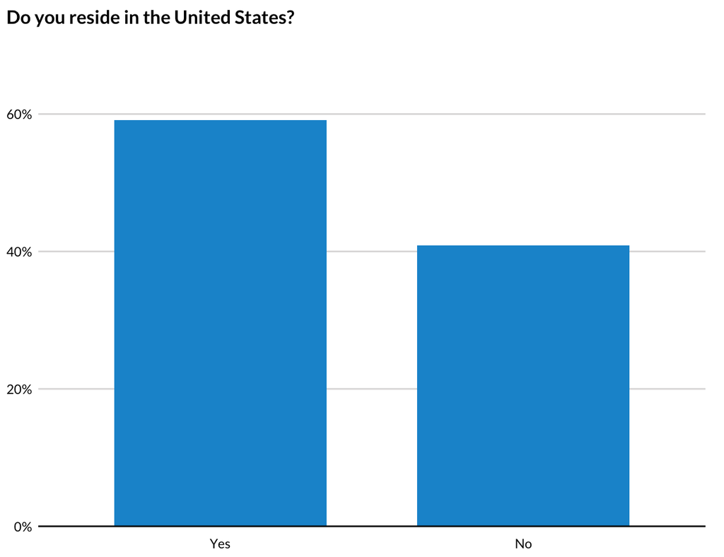

```r
aea_weighted %>%
  group_by(Q1_1) %>%
  summarize(survey_prop(vartype = "ci")) %>%
  mutate(Q1_1 = factor(Q1_1, levels = c("Yes", "No"))) %>%
  ggplot(aes(Q1_1, coef)) +
  geom_col() +
  scale_y_continuous(
    labels = scales::percent,
    expand = expansion(mult = c(0, 0.2))
  ) +
  labs(
    title = "Do you reside in the United States?",
    x = NULL,
    y = NULL
  ) +
  remove_ticks()
```

```r
aea_weighted %>%
  group_by(Q1_1) %>%
  summarize(survey_prop(vartype = "ci"))
```

| Q1_1 | coef | _low | _upp |
| --- | --- | --- | --- |
| No | 0.4087256 | 0.3757744 | 0.4425179 |
| Yes | 0.5912744 | 0.5574821 | 0.6242256 |

1.2: Are you currently a student?

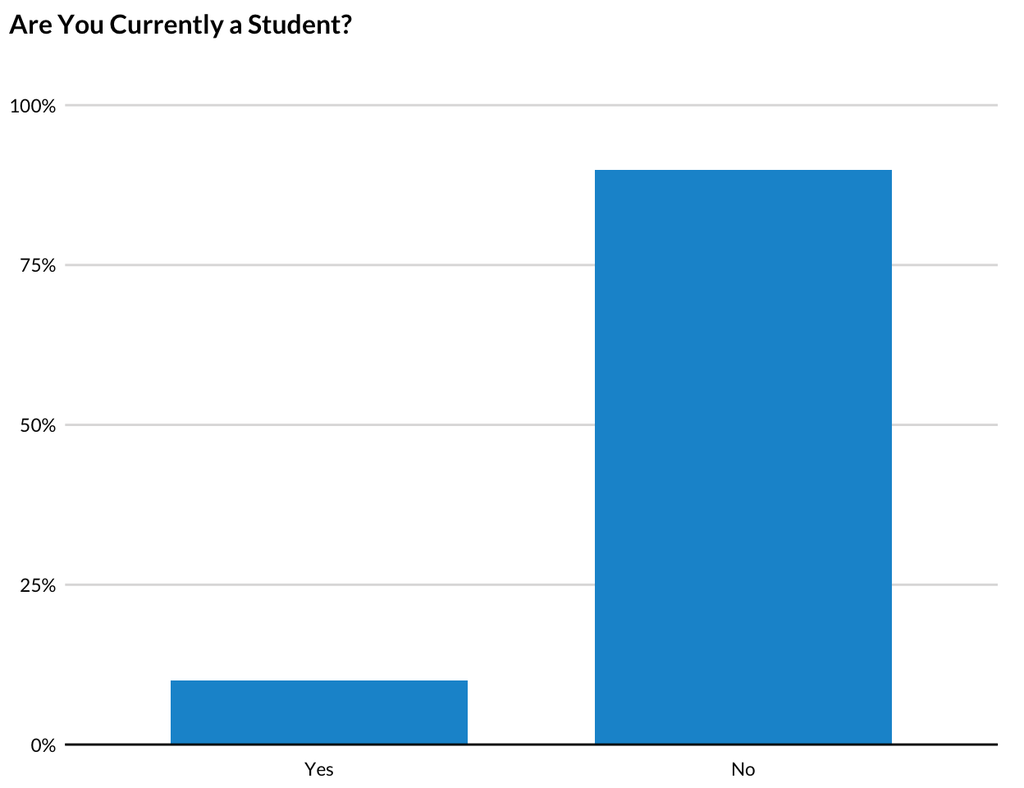

```r
aea_weighted %>%
  group_by(Q1_2) %>%
  summarize(n(), survey_prop(vartype = "ci")) %>%
  filter(!is.na(Q1_2)) %>%
  mutate(Q1_2 = factor(Q1_2, levels = c("Yes", "No"))) %>%
  ggplot(aes(Q1_2, coef)) +
  geom_col() +
  scale_y_continuous(
    labels = scales::percent,
    expand = expansion(mult = c(0, 0.2))
  ) +
  labs(
    title = "Are You Currently a Student?",
    x = NULL,
    y = NULL
  ) +
  remove_ticks()
```

```r
aea_weighted %>%
  group_by(Q1_2) %>%
  summarize(n(), survey_prop(vartype = "ci"))
```

| Q1_2 | n() | coef | _low | _upp |
| --- | --- | --- | --- | --- |
| No | 906 | 0.8989054774 | 0.8781632862 | 0.916452359 |
| Yes | 110 | 0.1003465663 | 0.0828508285 | 0.121049277 |
| NA | 1 | 0.0007479565 | 0.0001049664 | 0.005308781 |

1.3: What is the highest degree or level of school you have completed?

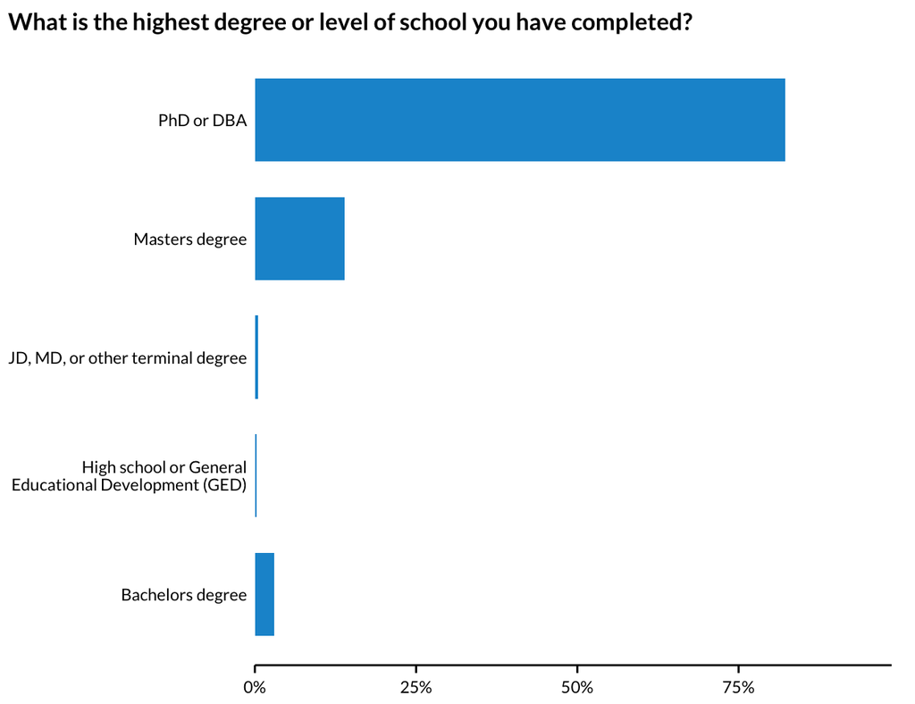

```r
aea_weighted %>%
  group_by(Q1_3) %>%
  summarize(n(), survey_prop(vartype = "ci")) %>%
  slice(1:5) %>%
  mutate(Q1_3 = fct_recode(
    Q1_3,
    `High school or General\nEducational Development (GED)` =
      "High school or General Educational Development (GED)")
  ) %>%
  ggplot(aes(coef, Q1_3)) +
  geom_col() +
  scale_x_continuous(
    labels = scales::percent,
    expand = expansion(mult = c(0, 0.2))
  ) +
  labs(
    title = "What is the highest degree or level of school you have completed?",
    x = NULL,
    y = NULL
  ) +
  theme(panel.grid = element_blank())
```

```r
aea_weighted %>%
  group_by(Q1_3) %>%
  summarize(n(), survey_prop(vartype = "ci"))
```

| Q1_3 | n() | coef | _low | _upp |
| --- | --- | --- | --- | --- |
| Bachelors degree | 23 | 0.0300394207 | 0.0199033268 | 0.045099954 |
| High school or General Educational Development (GED) | 2 | 0.0027105793 | 0.0006736331 | 0.010840073 |
| JD, MD, or other terminal degree | 11 | 0.0045000000 | 0.0023520790 | 0.008592511 |
| Masters degree | 159 | 0.1392500000 | 0.1188166326 | 0.162549157 |
| PhD or DBA | 821 | 0.8227520435 | 0.7968410261 | 0.845997044 |
| NA | 1 | 0.0007479565 | 0.0001049664 | 0.005308781 |

1.4: In what year did you finish your highest degree or level of school?

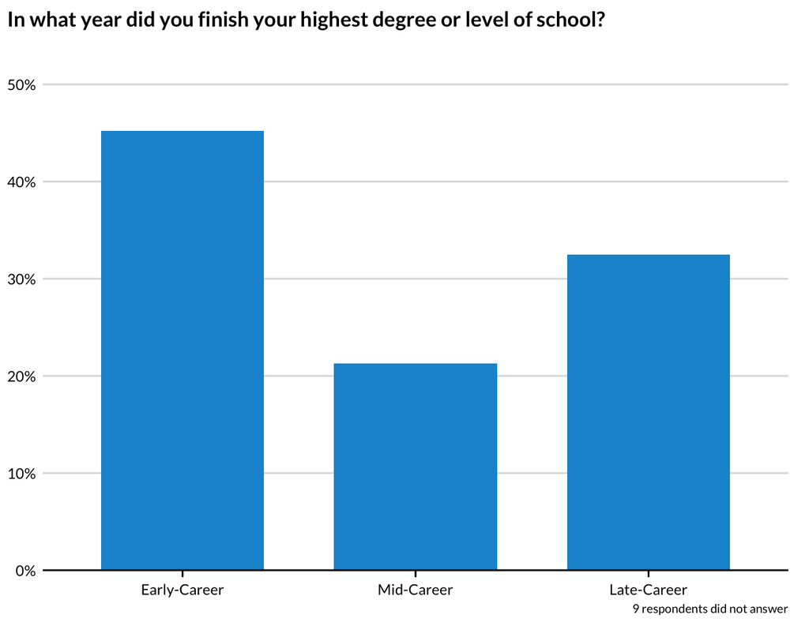

```r
missing_q1.4 <- sum(is.na(pull(aea_weighted, Q1_4)))

aea_weighted %>%
  group_by(Q1_4) %>%
  summarize(n(), survey_prop(vartype = "ci")) %>%
  filter(!is.na(Q1_4)) %>%
  mutate(Q1_4 = factor(Q1_4, levels = c("Early-Career", "Mid-Career", "Late-Career"))) %>%
  ggplot(aes(Q1_4, coef)) +
  geom_col() +
  scale_y_continuous(
    labels = scales::percent,
    expand = expansion(mult = c(0, 0.2))
  ) +
  labs(
    title = "In what year did you finish your highest degree or level of school?",
    x = NULL,
    y = NULL,
    caption = paste(missing_q1.4, "respondents did not answer")
  )
```

1.5: Which of the following best describes your most recent primary employer?

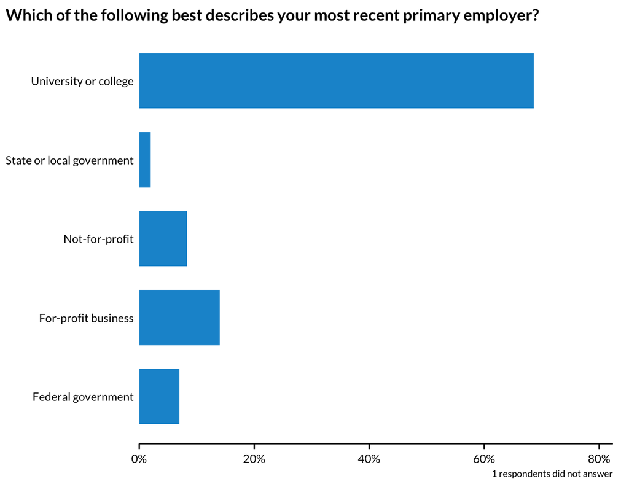

```r
missing_q1.5 <- sum(is.na(pull(aea_weighted, Q1_5)))

aea_weighted %>%
  group_by(Q1_5) %>%
  summarize(n(), survey_prop(vartype = "ci")) %>%
  filter(!is.na(Q1_5)) %>%
  ggplot(aes(coef, Q1_5)) +
  geom_col() +
  scale_x_continuous(
    labels = scales::percent,
    expand = expansion(mult = c(0, 0.2))
  ) +
  labs(
    title = "Which of the following best describes your most recent primary employer?",
    x = NULL,
    y = NULL,
    caption = paste(missing_q1.5, "respondents did not answer")
  ) +
  theme(panel.grid = element_blank())
```

```r
aea_weighted %>%
  group_by(Q1_5) %>%
  summarize(n(), survey_prop(vartype = "ci"))
```

| Q1_5 | n() | coef | _low | _upp |
| --- | --- | --- | --- | --- |
| Federal government | 103 | 0.0699534306 | 0.0569979023 | 0.085586463 |
| For-profit business | 117 | 0.1401614838 | 0.1178803693 | 0.165862188 |
| Not-for-profit | 68 | 0.0827702985 | 0.0654046620 | 0.104232473 |
| State or local government | 28 | 0.0196174279 | 0.0131415641 | 0.029190059 |
| University or college | 700 | 0.6866267465 | 0.6554036368 | 0.716245628 |
| NA | 1 | 0.0008706129 | 0.0001221927 | 0.006174739 |

1.6: Have you refereed at least one peer-reviewed journal article in the past five years?

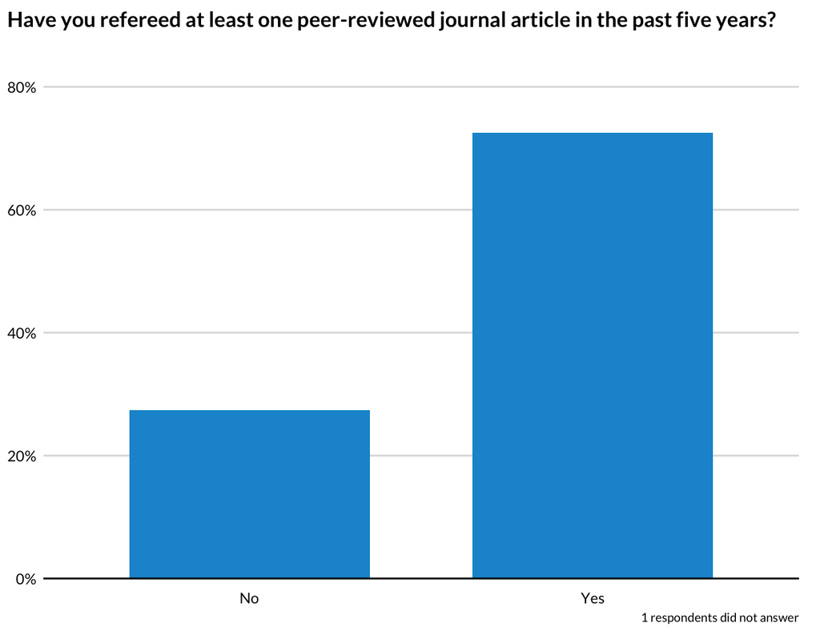

```r
missing_q1.6 <- sum(is.na(pull(aea_weighted, Q1_6)))

aea_weighted %>%
  group_by(Q1_6) %>%
  summarize(n(), survey_prop(vartype = "ci")) %>%
  filter(!is.na(Q1_6)) %>%
  ggplot(aes(Q1_6, coef)) +
  geom_col() +
  scale_y_continuous(
    labels = scales::percent,
    expand = expansion(mult = c(0, 0.2))
  ) +
  labs(
    title = "Have you refereed at least one peer-reviewed journal article in the past five years?",
    x = NULL,
    y = NULL,
    caption = paste(missing_q1.6, "respondents did not answer")
  ) +
  remove_ticks()
```

```r
aea_weighted %>%
  group_by(Q1_6) %>%
  summarize(n(), survey_prop(vartype = "ci"))
```

| Q1_6 | n() | coef | _low | _upp |
| --- | --- | --- | --- | --- |
| No | 299 | 0.2743402268 | 0.2466525001 | 0.303882295 |
| Yes | 717 | 0.7248285263 | 0.6952678633 | 0.752542253 |
| NA | 1 | 0.0008312469 | 0.0001166636 | 0.005896955 |

## 1.2 Section 2

Starting in section 2, we drop missing values before calculating proportions.

### 1.2.1 Question 1

Q2_1 - 2.1: Please rate the following methods based on how frequently you have used the method on cross-sectional data in the past year:

#### Visualization

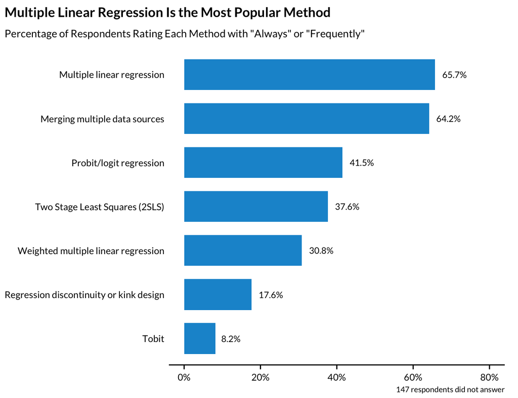

```r
responses <- c("Always", "Frequently")

aea_weighted %>%
  summarize(
    `Multiple linear regression` = survey_mean(Q2_1_1 %in% responses, na.rm = TRUE),
    `Weighted multiple linear regression` = survey_mean(Q2_1_2 %in% responses, na.rm = TRUE),
    `Tobit` = survey_mean(Q2_1_3 %in% responses, na.rm = TRUE),
    `Probit/logit regression` = survey_mean(Q2_1_4 %in% responses, na.rm = TRUE),
    `Regression discontinuity or kink design` = survey_mean(Q2_1_5 %in% responses, na.rm = TRUE),
    `Merging multiple data sources` = survey_mean(Q2_1_6 %in% responses, na.rm = TRUE),
    `Two Stage Least Squares (2SLS)` = survey_mean(Q2_1_7 %in% responses, na.rm = TRUE)
  ) %>%
  select(!ends_with("_se")) %>%
  pivot_longer(
    everything(),
    names_to = "Method",
    values_to = "Proportion 'Always' or 'Frequently'"
  ) %>%
  mutate(Method = fct_reorder(Method, `Proportion 'Always' or 'Frequently'`)) %>%
  ggplot(aes(x = `Proportion 'Always' or 'Frequently'`, y = Method)) +
  geom_col() +
  geom_text(aes(label = label_percent(accuracy = 0.1)(`Proportion 'Always' or 'Frequently'`), hjust = -0.3)) +
  scale_x_continuous(
    labels = scales::percent,
    limits = c(0, 0.8)
  ) +
  labs(
    title = "Multiple Linear Regression Is the Most Popular Method",
    subtitle = 'Percentage of Respondents Rating Each Method with "Always" or "Frequently"',
    x = NULL,
    y = NULL,
    caption = "147 respondents did not answer"
  ) +
  theme(panel.grid = element_blank())
```

#### Table

```r
survey_count(aea_weighted, missing_all = is.na(Q2_1_1) & is.na(Q2_1_2) & is.na(Q2_1_3) & is.na(Q2_1_4) & is.na(Q2_1_5) & is.na(Q2_1_6) & is.na(Q2_1_7))
```

| missing_all | n | n_se |
| --- | --- | --- |
| FALSE | 878.7164 | 14.82590 |
| TRUE | 138.2836 | 11.82752 |

Multiple linear regression

```r
survey_count(aea_weighted, Q2_1_1)
```

| Q2_1_1 | n | n_se |
| --- | --- | --- |
| Always | 286.43186 | 15.337786 |
| Frequently | 381.88695 | 17.164926 |
| Infrequently | 113.71757 | 10.573983 |
| Never | 83.66063 | 8.928643 |
| NA | 151.30298 | 12.273885 |

Weighted multiple linear regression

```r
survey_count(aea_weighted, Q2_1_2)
```

| Q2_1_2 | n | n_se |
| --- | --- | --- |
| Always | 71.44559 | 8.383639 |
| Frequently | 241.85074 | 14.590218 |
| Infrequently | 283.63082 | 15.546964 |
| Never | 253.02766 | 14.650455 |
| NA | 167.04519 | 12.912943 |

Tobit

```r
survey_count(aea_weighted, Q2_1_3)
```

| Q2_1_3 | n | n_se |
| --- | --- | --- |
| Always | 12.48527 | 3.709960 |
| Frequently | 71.10809 | 8.902529 |
| Infrequently | 295.08383 | 15.872968 |
| Never | 443.07062 | 16.975778 |
| NA | 195.25219 | 13.556480 |

Probit/logit regression

```r
survey_count(aea_weighted, Q2_1_4)
```

| Q2_1_4 | n | n_se |
| --- | --- | --- |
| Always | 75.27789 | 8.993836 |
| Frequently | 346.27524 | 16.607405 |
| Infrequently | 264.81257 | 15.117250 |
| Never | 166.21471 | 11.959143 |
| NA | 164.41959 | 12.799876 |

Regression discontinuity or kink design

```r
survey_count(aea_weighted, Q2_1_5)
```

| Q2_1_5 | n | n_se |
| --- | --- | --- |
| Always | 21.42923 | 4.945512 |
| Frequently | 157.62594 | 12.557365 |
| Infrequently | 283.04392 | 15.044116 |
| Never | 385.03765 | 16.860883 |
| NA | 169.86326 | 12.948513 |

Merging multiple data sources

```r
survey_count(aea_weighted, Q2_1_6)
```

| Q2_1_6 | n | n_se |
| --- | --- | --- |
| Always | 306.53114 | 15.684690 |
| Frequently | 346.09734 | 16.635560 |
| Infrequently | 97.20694 | 9.876406 |
| Never | 111.78210 | 10.438091 |
| NA | 155.38247 | 12.390000 |

Two Stage Least Squares (2SLS)

```r
survey_count(aea_weighted, Q2_1_7)
```

| Q2_1_7 | n | n_se |
| --- | --- | --- |
| Always | 48.68272 | 7.330869 |
| Frequently | 333.94156 | 16.496273 |
| Infrequently | 263.83733 | 15.099560 |
| Never | 215.85838 | 13.517431 |
| NA | 154.68002 | 12.324680 |

### 1.2.2 Question 2

See analysis-text.qmd.

### 1.2.3 Question 3

2.3: Please rate the following information obtained from multiple linear regression based on its importance for your work:

#### Visualization

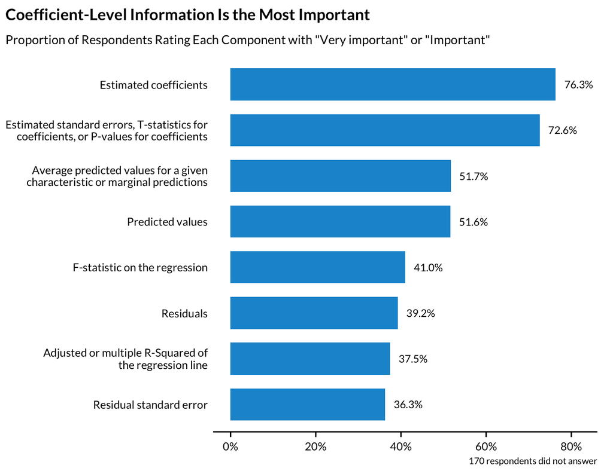

```r
responses <- c("Very important", "Important")

aea_weighted %>%
  summarize(
    `Estimated coefficients` = survey_mean(Q2_3_1 %in% responses, na.rm = TRUE),
    `Estimated standard errors, T-statistics for\ncoefficients, or P-values for coefficients` = mean(Q2_3_2 %in% responses, na.rm = TRUE),
    `Adjusted or multiple R-Squared of\nthe regression line` = survey_mean(Q2_3_3 %in% responses, na.rm = TRUE),
    `F-statistic on the regression` = survey_mean(Q2_3_4 %in% responses, na.rm = TRUE),
    `Residuals` = mean(Q2_3_5 %in% responses, na.rm = TRUE),
    `Residual standard error` = survey_mean(Q2_3_6 %in% responses, na.rm = TRUE),
    `Predicted values` = survey_mean(Q2_3_7 %in% responses, na.rm = TRUE),
    `Average predicted values for a given\ncharacteristic or marginal predictions` = survey_mean(Q2_3_8 %in% responses, na.rm = TRUE)
  ) %>%
  select(!ends_with("_se")) %>%
  pivot_longer(
    everything(),
    names_to = "Method",
    values_to = "Proportion 'Very important' or 'Important'"
  ) %>%
  mutate(Method = fct_reorder(Method, `Proportion 'Very important' or 'Important'`)) %>%
  ggplot(aes(x = `Proportion 'Very important' or 'Important'`, y = Method)) +
  geom_col() +
  geom_text(aes(label = label_percent(accuracy = 0.1)(`Proportion 'Very important' or 'Important'`), hjust = -0.3)) +
  scale_x_continuous(
    labels = scales::percent,
    limits = c(0, 0.82)
  ) +
  labs(
    title = "Coefficient-Level Information Is the Most Important",
    subtitle = 'Proportion of Respondents Rating Each Component with "Very important" or "Important"',
    x = NULL,
    y = NULL,
    caption = "170 respondents did not answer"
  ) +
  theme(panel.grid = element_blank())
```

#### Table

```r
survey_count(aea_weighted, missing_all = is.na(Q2_3_1) & is.na(Q2_3_2) & is.na(Q2_3_3) & is.na(Q2_3_4) & is.na(Q2_3_5) & is.na(Q2_3_6) & is.na(Q2_3_7) & is.na(Q2_3_8))
```

| missing_all | n | n_se |
| --- | --- | --- |
| FALSE | 858.2295 | 15.29797 |
| TRUE | 158.7705 | 12.43801 |

Estimated coefficients

```r
survey_count(aea_weighted, Q2_3_1)
```

| Q2_3_1 | n | n_se |
| --- | --- | --- |
| Important | 259.18663 | 15.133390 |
| Not at all important | 26.32777 | 4.975855 |
| Somewhat important | 49.07490 | 7.484926 |
| Very important | 517.03872 | 17.596537 |
| NA | 165.37198 | 12.643257 |

Estimated standard errors, T-statistics for coefficients, or P-values for coefficients

```r
survey_count(aea_weighted, Q2_3_2)
```

| Q2_3_2 | n | n_se |
| --- | --- | --- |
| Important | 258.36672 | 15.153294 |
| Not at all important | 30.24975 | 5.259368 |
| Somewhat important | 80.90343 | 9.389313 |
| Very important | 482.08967 | 17.437822 |
| NA | 165.39043 | 12.659494 |

Adjusted or multiple R-Squared of the regression line

```r
survey_count(aea_weighted, Q2_3_3)
```

| Q2_3_3 | n | n_se |
| --- | --- | --- |
| Important | 255.1854 | 14.81801 |
| Not at all important | 115.0406 | 10.34588 |
| Somewhat important | 347.0257 | 16.64859 |
| Very important | 125.7790 | 11.41457 |
| NA | 173.9692 | 12.78330 |

F-statistic on the regression

```r
survey_count(aea_weighted, Q2_3_4)
```

| Q2_3_4 | n | n_se |
| --- | --- | --- |
| Important | 291.6894 | 15.66898 |
| Not at all important | 132.4536 | 11.05274 |
| Somewhat important | 288.3776 | 15.78717 |
| Very important | 125.6824 | 11.12747 |
| NA | 178.7970 | 12.95730 |

Residuals

```r
survey_count(aea_weighted, Q2_3_5)
```

| Q2_3_5 | n | n_se |
| --- | --- | --- |
| Important | 278.85834 | 15.464465 |
| Not at all important | 88.27981 | 9.246653 |
| Somewhat important | 335.88487 | 16.449135 |
| Very important | 122.61061 | 10.950079 |
| NA | 191.36638 | 13.314732 |

Residual standard error

```r
survey_count(aea_weighted, Q2_3_6)
```

| Q2_3_6 | n | n_se |
| --- | --- | --- |
| Important | 257.6876 | 15.27684 |
| Not at all important | 132.5708 | 11.07077 |
| Somewhat important | 325.6080 | 16.28297 |
| Very important | 111.0842 | 10.30976 |
| NA | 190.0494 | 13.28269 |

Predicted values

```r
survey_count(aea_weighted, Q2_3_7)
```

| Q2_3_7 | n | n_se |
| --- | --- | --- |
| Important | 342.7926 | 16.476648 |
| Not at all important | 64.8800 | 8.044253 |
| Somewhat important | 249.3630 | 14.873478 |
| Very important | 181.9823 | 12.964947 |
| NA | 177.9821 | 12.970143 |

Average predicted values for a given characteristic or marginal predictions

```r
survey_count(aea_weighted, Q2_3_8)
```

| Q2_3_8 | n | n_se |
| --- | --- | --- |
| Important | 320.99231 | 16.123097 |
| Not at all important | 84.05929 | 9.029468 |
| Somewhat important | 229.88188 | 14.482742 |
| Very important | 204.60734 | 13.695698 |
| NA | 177.45918 | 12.927172 |

### 1.2.4 Question 5

See analysis-text.qmd.

## 1.3 Section 3

### 1.3.1 Question 1

Q3_1 - 3.1: Please rate your familiarity with the concept of differential privacy.

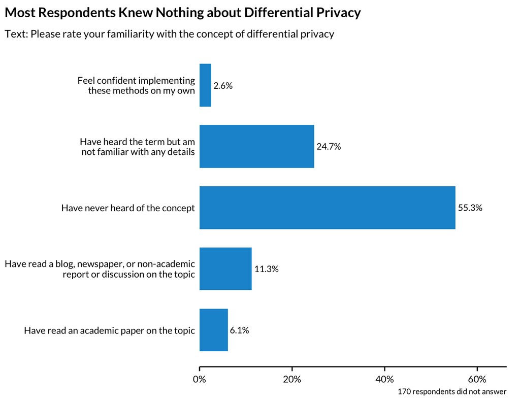

```r
missing_q3.1 <- sum(is.na(pull(aea_weighted, Q3_1)))

aea_weighted %>%
  filter(!is.na(Q3_1)) %>%
  group_by(Q3_1) %>%
  summarize(n(), survey_prop(vartype = "ci")) %>%
  mutate(Q3_1 = fct_recode(
    Q3_1,
    `Have heard the term but am\nnot familiar with any details` =
      "Have heard the term but am not familiar with any details",
    `Have read a blog, newspaper, or non-academic\nreport or discussion on the topic` =
      "Have read a blog, newspaper, or non-academic report or discussion on the topic",
    `Feel confident implementing\nthese methods on my own` =
      "Feel confident implementing these methods on my own")
  ) %>%
  mutate(Q3_1 = fct_rev(Q3_1)) %>%
  ggplot(aes(coef, Q3_1)) +
  geom_col() +
  geom_text(aes(label = label_percent(accuracy = 0.1)(coef), hjust = -0.1)) +
  scale_x_continuous(
    labels = scales::percent,
    expand = expansion(mult = c(0, 0.2))
  ) +
  labs(
    title = "Most Respondents Knew Nothing about Differential Privacy",
    subtitle = "Text: Please rate your familiarity with the concept of differential privacy",
    x = NULL,
    y = NULL,
    caption = paste(missing_q3.1, "respondents did not answer")
  ) +
  theme(panel.grid = element_blank())
```

```r
aea_weighted %>%
  filter(!is.na(Q3_1)) %>%
  group_by(Q3_1) %>%
  summarize(n(), survey_prop(vartype = "ci"))
```

| Q3_1 | n() | coef | _low | _upp |
| --- | --- | --- | --- | --- |
| Feel confident implementing these methods on my own | 23 | 0.02557907 | 0.01662116 | 0.03917251 |
| Have heard the term but am not familiar with any details | 206 | 0.24738663 | 0.21782027 | 0.27953201 |
| Have never heard of the concept | 454 | 0.55301851 | 0.51745515 | 0.58804747 |
| Have read a blog, newspaper, or non-academic report or discussion on the topic | 105 | 0.11282925 | 0.09283450 | 0.13648257 |
| Have read an academic paper on the topic | 59 | 0.06118654 | 0.04691340 | 0.07944026 |

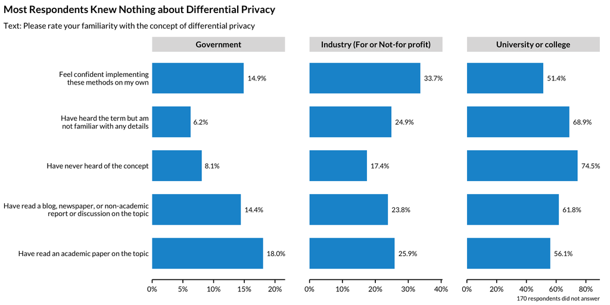

```r
missing_q3.1_employer <- sum(is.na(pull(aea_weighted, Q3_1)) | is.na(pull(aea_weighted, Q1_5)))

aea_weighted %>%
  filter(
    !is.na(as.character(Q3_1)),
    !is.na(as.character(Q1_5))
  ) %>%
  mutate(
    Q1_5 = fct_recode(
      Q1_5,
      `Industry (For or Not-for profit)` = "For-profit business",
      `Industry (For or Not-for profit)` = "Not-for-profit",
      `Government` = "Federal government",
      `Government` = "State or local government"
    )
  ) %>%
  group_by(Q3_1, Q1_5) %>%
  summarize(n(), survey_prop(vartype = "ci")) %>%
  ungroup() %>%
  mutate(Q3_1 = fct_recode(
    Q3_1,
    `Have heard the term but am\nnot familiar with any details` =
      "Have heard the term but am not familiar with any details",
    `Have read a blog, newspaper, or non-academic\nreport or discussion on the topic` =
      "Have read a blog, newspaper, or non-academic report or discussion on the topic",
    `Feel confident implementing\nthese methods on my own` =
      "Feel confident implementing these methods on my own")
  ) %>%
  mutate(Q3_1 = fct_rev(Q3_1)) %>%
  ggplot(aes(coef, Q3_1)) +
  geom_col() +
  geom_text(aes(label = label_percent(accuracy = 0.1)(coef), hjust = -0.2)) +
  scale_x_continuous(
    labels = scales::percent,
    expand = expansion(mult = c(0, 0.2))
  ) +
  facet_wrap(~Q1_5, scales = "free_x") +
  labs(
    title = "Most Respondents Knew Nothing about Differential Privacy",
    subtitle = "Text: Please rate your familiarity with the concept of differential privacy",
    x = NULL,
    y = NULL,
    caption = paste(missing_q3.1_employer, "respondents did not answer")
  ) +
  theme(
    panel.grid = element_blank(),
    panel.spacing = unit(2, "lines")
  )
```

```r
aea_weighted %>%
  filter(
    !is.na(as.character(Q3_1)),
    !is.na(as.character(Q1_5))
  ) %>%
  mutate(
    Q1_5 = fct_recode(
      Q1_5,
      `Industry (For or Not-for profit)` = "For-profit business",
      `Industry (For or Not-for profit)` = "Not-for-profit",
      `Government` = "Federal government",
      `Government` = "State or local government"
    )
  ) %>%
  group_by(Q3_1, Q1_5) %>%
  summarize(n(), survey_prop(vartype = "ci")) %>%
  ungroup()
```

| Q3_1 | Q1_5 | n() | coef | _low | _upp |
| --- | --- | --- | --- | --- | --- |
| Feel confident implementing these methods on my own | Government | 6 | 0.14913925 | 0.06307404 | 0.3133635 |
| Feel confident implementing these methods on my own | Industry (For or Not-for profit) | 6 | 0.33673777 | 0.16376304 | 0.5682610 |
| Feel confident implementing these methods on my own | University or college | 11 | 0.51412299 | 0.30757633 | 0.7159558 |
| Have heard the term but am not familiar with any details | Government | 18 | 0.06240855 | 0.03782937 | 0.1012768 |
| Have heard the term but am not familiar with any details | Industry (For or Not-for profit) | 42 | 0.24901047 | 0.18955358 | 0.3197589 |
| Have heard the term but am not familiar with any details | University or college | 146 | 0.68858098 | 0.61692279 | 0.7522186 |
| Have never heard of the concept | Government | 50 | 0.08094482 | 0.06035400 | 0.1077550 |
| Have never heard of the concept | Industry (For or Not-for profit) | 66 | 0.17408909 | 0.13851812 | 0.2164990 |
| Have never heard of the concept | University or college | 338 | 0.74496609 | 0.69995303 | 0.7852976 |
| Have read a blog, newspaper, or non-academic report or discussion on the topic | Government | 22 | 0.14422247 | 0.09325869 | 0.2163904 |

[output cut: 5 more lines]

### 1.3.2 Question 2

Q3_2 - 3.2: Please rate your familiarity with the concept of formal privacy

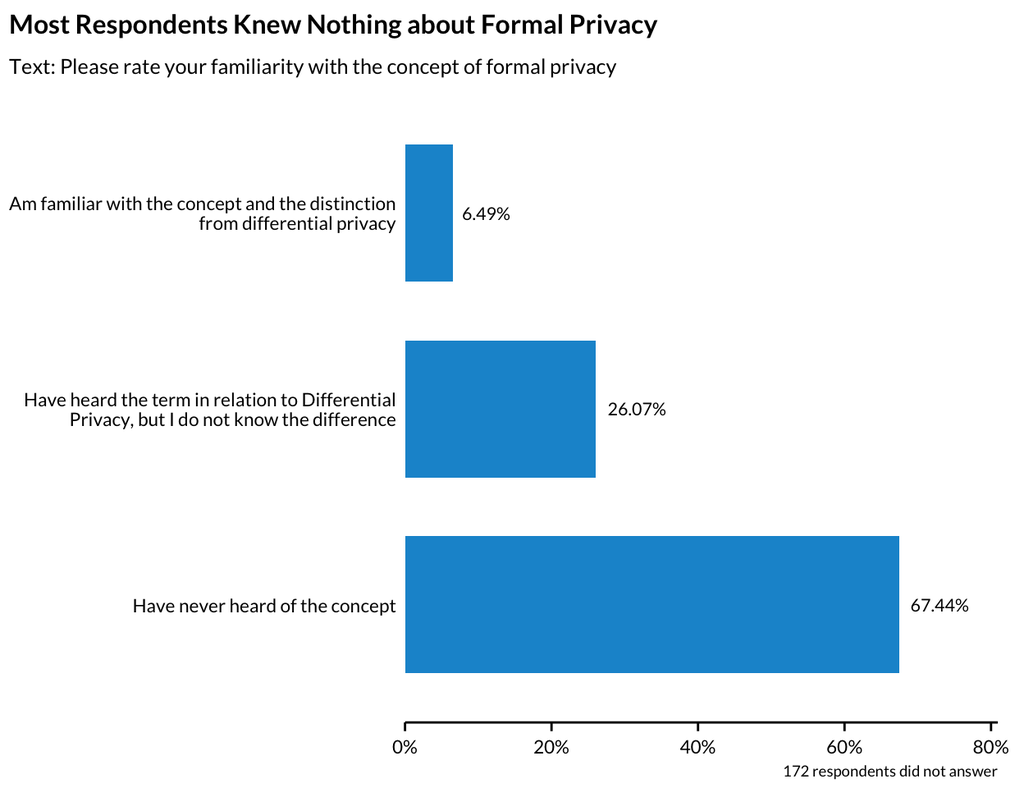

```r
missing_q3.2 <- sum(is.na(pull(aea_weighted, Q3_2)))

aea_weighted %>%
  filter(!is.na(Q3_2)) %>%
  group_by(Q3_2) %>%
  summarize(n(), survey_prop(vartype = "ci")) %>%
  mutate(Q3_2 = fct_recode(
    Q3_2,
    `Have heard the term in relation to Differential\nPrivacy, but I do not know the difference` =
      "Have heard the term in relation to Differential Privacy, but I do not know the difference",
    `Am familiar with the concept and the distinction\nfrom differential privacy` =
      "Am familiar with the concept and the distinction from differential privacy")
  ) %>%
  mutate(Q3_2 = fct_rev(Q3_2)) %>%
  ggplot(aes(coef, Q3_2)) +
  geom_col() +
  geom_text(aes(label = label_percent(accuracy = 0.01)(coef), hjust = -0.2)) +
  scale_x_continuous(
    labels = scales::percent,
    expand = expansion(mult = c(0, 0.2))
  ) +
  labs(
    title = "Most Respondents Knew Nothing about Formal Privacy",
    subtitle = "Text: Please rate your familiarity with the concept of formal privacy",
    x = NULL,
    y = NULL,
    caption = paste(missing_q3.2, "respondents did not answer")
  ) +
  theme(panel.grid = element_blank())
```

```r
aea_weighted %>%
  filter(!is.na(Q3_2)) %>%
  group_by(Q3_2) %>%
  summarize(n(), survey_prop(vartype = "ci"))
```

| Q3_2 | n() | coef | _low | _upp |
| --- | --- | --- | --- | --- |
| Am familiar with the concept and the distinction from differential privacy | 58 | 0.06492183 | 0.04961541 | 0.0845303 |
| Have heard the term in relation to Differential Privacy, but I do not know the difference | 227 | 0.26066268 | 0.23081933 | 0.2928953 |
| Have never heard of the concept | 560 | 0.67441549 | 0.64037440 | 0.7067101 |

### 1.3.3 Question 3

Q3_3 - 3.3: What share of economists you know in your professional circles have discussed the US Census Bureau’s adoption of differential privacy/formal privacy for the 2020 Census?

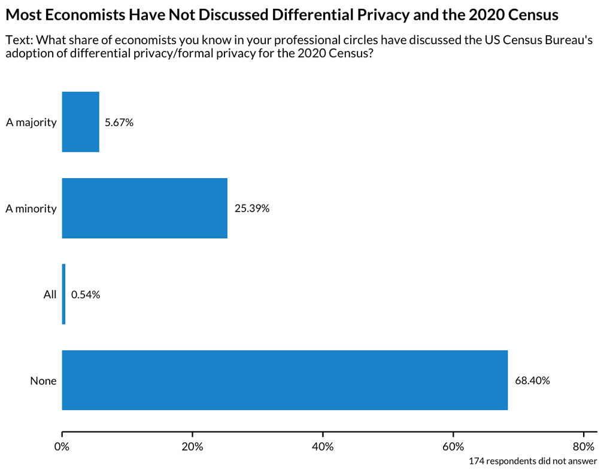

```r
missing_q3.3 <- sum(is.na(pull(aea_weighted, Q3_3)))

aea_weighted %>%
  filter(!is.na(Q3_3)) %>%
  group_by(Q3_3) %>%
  summarize(n(), survey_prop(vartype = "ci")) %>%
  mutate(Q3_3 = fct_rev(Q3_3)) %>%
  ggplot(aes(coef, Q3_3)) +
  geom_col() +
  geom_text(aes(label = label_percent(accuracy = 0.01)(coef), hjust = -0.2)) +
  scale_x_continuous(
    labels = scales::percent,
    expand = expansion(mult = c(0, 0.2))
  ) +
  labs(
    title = "Most Economists Have Not Discussed Differential Privacy and the 2020 Census",
    subtitle = "Text: What share of economists you know in your professional circles have discussed the US Census Bureau's\nadoption of differential privacy/formal privacy for the 2020 Census?",
    x = NULL,
    y = NULL,
    caption = paste(missing_q3.3, "respondents did not answer")
  ) +
  theme(panel.grid = element_blank())
```

### 1.3.4 Question 4

Q3_4 - 3.4: What share of economists you know in your professional circles work with differential privacy/formal privacy methods?

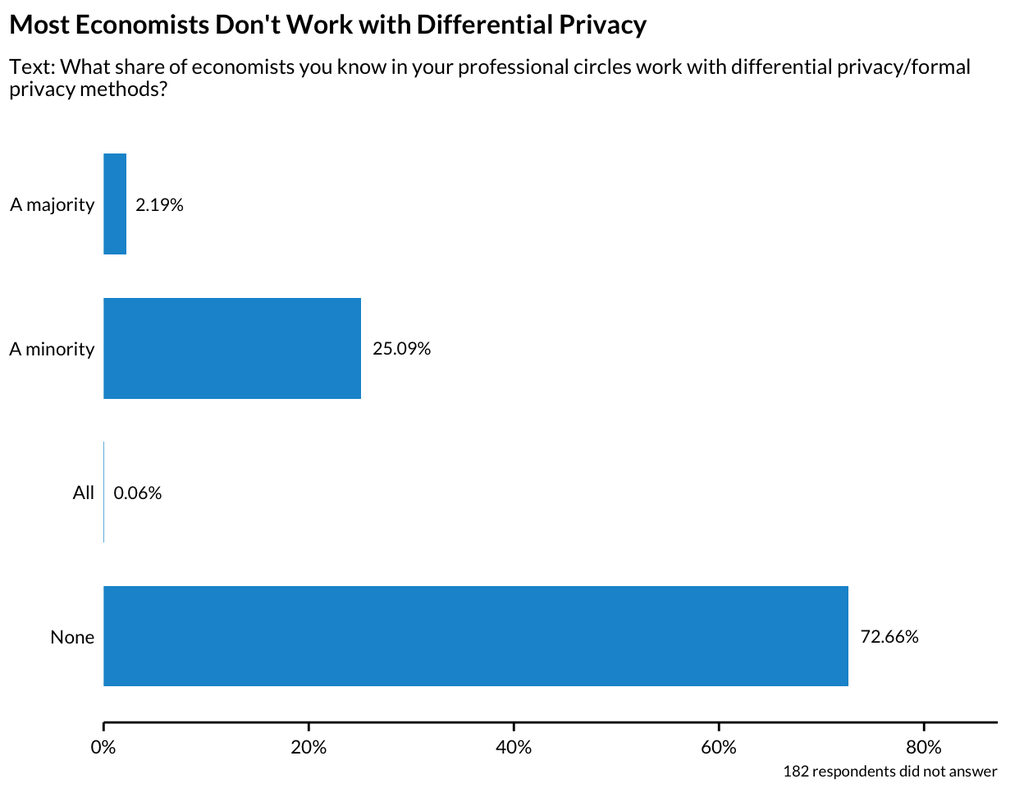

```r
missing_q3.4 <- sum(is.na(pull(aea_weighted, Q3_4)))

aea_weighted %>%
  filter(!is.na(Q3_4)) %>%
  group_by(Q3_4) %>%
  summarize(n(), survey_prop(vartype = "ci")) %>%
  mutate(Q3_4 = fct_rev(Q3_4)) %>%
  ggplot(aes(coef, Q3_4)) +
  geom_col() +
  geom_text(aes(label = label_percent(accuracy = 0.01)(coef), hjust = -0.2)) +
  scale_x_continuous(
    labels = scales::percent,
    expand = expansion(mult = c(0, 0.2))
  ) +
  labs(
    title = "Most Economists Don't Work with Differential Privacy",
    subtitle = "Text: What share of economists you know in your professional circles work with differential privacy/formal\nprivacy methods?",
    x = NULL,
    y = NULL,
    caption = paste(missing_q3.4, "respondents did not answer")
  ) +
  theme(panel.grid = element_blank())
```